# Reinforcement Learning Projet

**Authors:**

- SIDIBE Bakary
- BALL Alhousseynou
- DIOP Seyni

**Article:** : [An Emphatic Approach to the Problem of Off-policy Temporal-Difference Learning --- Richard S. Sutton, A. Rupam Mahmood and Martha White (2015)](https://arxiv.org/abs/1503.04269)

Summary

## 1. Introduction

## 2. Notations and definitions

## 3. Emphatic TD update equations

#### 3.1 Emphatic TD(0)

#### 3.2 Emphatic TD($\lambda$)

#### 3.3 MSVE for emphatic TD

#### 3.4 Theorem (Emphatic TD Stability)

## 4. Implementations

#### 4.1 Import Necessary packages

#### 4.2 Policies definition

#### 4.3 Model definiton

#### 4.4 Parametric Temporal Difference: TD($\lambda$)

#### 4.5 Parameters tuning

## 5. Comments on Results and Intuition

## 6. Perspectives

Introduction

Temporal-difference (TD) learning is perhaps the most important idea to come out of the field of reinforcement learning. The problem it solves is that of efficiently learning to make a sequence of long-term predictions about how a dynamical system will evolve over time.The key idea is to use the change (temporal difference) from one prediction to the next as an error in the earlier prediction.The TD approach is more convenient computationally because it requires less memory and because its computations are spread out uniformly over the year (rather than being bunched together all at the end of the year) for example.

In this notebook we explore an approach to solving the problem of off-policy TD learning with function approximation which aims to create a weighting equivalent to the followon distribution for the target policy started in the stationary distribution of the behavior policy.

Our main goal is to prove that varying emphasis according to the followon distribution produces a new version of linear TD($\lambda$)(parametric TD), *called emphatic TD($\lambda$)* , that is stable under general off-policy training.

Notations and definitions

- state: $x \in \mathcal{X}$
- action: $a \in \mathcal{A}$
- policy: $\pi : \mathcal{X} \times \mathcal{A} \mapsto[0,1]$
- State value of s: $v_{\pi}(s)$
- behavior policy: $\mu : \mathcal{X} \times \mathcal{A} \mapsto[0,1]$
- discount factor: $\gamma \in[0,1)$
- Temporal Difference: TD
- Parametric TD Method: TD($\lambda$) and $\lambda$ is the parameter
- Simplest Parametric TD Method: TD(0)
- Followon trace: $F_{t}$
- Step-size: $\alpha$
- Feature vector of s: $\phi(s)$
- Parameter vector at time step t: $\theta_t$
- Reward $R$
- return at time $t$: $G_t$
- $A_t$ and $b_t$ are random variables which vary from time to time
- $d_{\pi}$ Steady-state distribution under $\pi$
- $P{\pi}$: matrix of $NxN$ transition of probabilities
- $\rho_t$: importance sampling ratio at time t
- Root Mean Squared Value Error: RMSVE
- “$\doteq$” indicates an equality by definition

Emphatic TD update equations

### - Emphatic TD(0)

\begin{array}{c} {F_{t} \doteq \gamma \rho_{t-1} F_{t-1}+1, \quad \forall t>0} \\ {\boldsymbol{\theta}_{t+1} \doteq \boldsymbol{\theta}_{t}+\alpha F_{t} \rho_{t}\left(R_{t+1}+\gamma \boldsymbol{\theta}_{t}^{\top} \boldsymbol{\phi}_{t+1}-\boldsymbol{\theta}_{t}^{\top} \boldsymbol{\phi}_{t}\right) \boldsymbol{\phi}_{t}} \\ {=\boldsymbol{\theta}_{t}+\alpha(\underbrace{F_{t} \rho_{t} R_{t+1} \boldsymbol{\phi}_{t}}_{\mathbf{b}_{t}}-\underbrace{\left.F_{t} \rho_{t} \boldsymbol{\phi}_{t}\left(\boldsymbol{\phi}_{t}-\gamma \boldsymbol{\phi}_{t+1}\right)^{\top} \boldsymbol{\theta}_{t}\right)}_{\mathbf{A}_{t}}} \end{array}

### - Emphatic TD($\lambda$)

$$\begin{aligned} \boldsymbol{\theta}_{t+1} & \doteq \boldsymbol{\theta}_{t}+\alpha\left(R_{t+1}+\gamma_{t+1} \boldsymbol{\theta}_{t}^{\top} \boldsymbol{\phi}_{t+1}-\boldsymbol{\theta}_{t}^{\top} \boldsymbol{\phi}_{t}\right) \mathbf{e}_{t} \\ \mathbf{e}_{t} & \doteq \rho_{t}\left(\gamma_{t} \lambda_{t} \mathbf{e}_{t-1}+M_{t} \boldsymbol{\phi}_{t}\right), \quad \text { with } \mathbf{e}_{-1} \doteq \mathbf{0} \\ M_{t} & \doteq \lambda_{t} i\left(S_{t}\right)+\left(1-\lambda_{t}\right) F_{t} \\ F_{t} & \doteq \rho_{t-1} \gamma_{t} F_{t-1}+i\left(S_{t}\right), \quad \text { with } F_{0} \doteq i\left(S_{0}\right) \end{aligned}$$

### - RMSVE of Emphatic TD learning

$$\operatorname{MSVE}(\boldsymbol{\theta}) \doteq \sum_{s \in \mathcal{B}} d_{\mu}(s) i(s)\left(v_{\pi}(s)-\boldsymbol{\theta}^{\top} \boldsymbol{\phi}(s)\right)^{2}$$

### - Theorem (Stability of Emphatic TD($\lambda$)) for any

> - Markov decision process $\{S_t, A_t, R_{t+1} \}_{t=0}^\infty$ with finite state and actions sets S and A,
> - behavior policy $\mu$ with a stationary invariant distribution $d_{\mu}(s) > 0, \forall s \in S$
> - target policy $\pi$ with coverage, i.e., s.t., if $\pi(a|s) > 0$, then $\mu(a|s) > 0$
> - discount function $\gamma: S \rightarrow [0,1]$ s.t. $\Pi_{k=1}^{\inf}\gamma(S_{t+k}) = 0 $, w.p.1, $\forall t > 0$
> - boostrapping function $\lambda: S \rightarrow [0,1], $
> - interest function $i: S \rightarrow (0, \infty), $
> - feature function $\phi: S \rightarrow \mathbb{R}^n$ s.t. the matrix $ \mathbb{R}^{|S|xn} $ with $\phi(s)$ as its rows has linearly independent columns,

the $A$ matrix of linear emphatic TD($\lambda)$ and assuming the existence of $\lim_{t \rightarrow \infty} \mathbb{E}_{\mu}[F_t|S_t = s] $ and $\lim_{t \rightarrow \infty} \mathbb{E}_{\mu}[e_t|S_t = s], \forall s \in S$

$$ A = \lim_{t \rightarrow \infty} \mathbb{E}_{\mu}[A_t] = \lim_{t \rightarrow \infty} \mathbb{E}_{\mu}[e_t(\phi_t - \gamma_{t+1} \phi_{t+1})^T] = \Phi^T M (I - P_{\pi}^{\lambda}) \phi,$$

is positive definite. *Thus, the algorithm and its expected update are stable*

Implementations

### - Import necessary packages

```python
# Usual imports
import numpy as np
import matplotlib.pyplot as plt

from utils import to_array_of_vectors
from scipy.optimize import minimize


import itertools


from utils import custom_mult

import sys
# sys.path.insert(0, "../library/") # Path of the library

from utils import comparatorTD # Tool to evaluate the TD algorithms on a model
```

```python
# To make nice plot for Latex
%matplotlib notebook
plt.rcParams.update({'font.size': 13}) # for Latex
plt.rcParams['figure.figsize'] = [8, 5]
```

### - Policies definition

```python
class Policy(object):
    '''
        Store a markov chain policy
        It basically stores the matrix of transition P.
        It adds helpful function to compute the next steps from multiple states (efficient)
    '''

    def __init__(self, P):
        '''
            Just store P and compute its stationary distrubution
        '''
        self.P = np.array(P)

        self._load_stationary()

        return self


    def fit(self, model):
        '''Do nothing here because P is already defined
            Else it should compute P according to the model
            Must return the fitted policy !!'''
        return self

    def _load_stationary(self):
        ''' Return the stationary distribution of the markov chain P '''

        a = self.P
        for _ in range(15):
            a = np.dot(a, a)
        pi_t = a[0]
        self.d = pi_t.flatten()
        self.D = np.diag(self.d)

    def next_step(self, s):
        '''  Pick a state according to the mass distribution of s '''
        P = self.P[s]
        m = len(P)
        return int(np.random.choice(np.arange(m), 1, p = list(P)))

    def parallel_steps(self, S):
        ''' Pick the next step for all the states in S (in parallel) '''
        S_new = S.copy()
        for s in np.unique(S):
            idxs = np.where(S == s)
            n = len(idxs[0]) # Number of chain in state s
            S_new[idxs] = np.random.choice(len(self.P), n, p = self.P[s])
        return S_new

    def __str__(self):
        if hasattr(self, 'P'): # the policy is defined
            res = "Transition matrix :\n"
            res += str(self.P) + "\n"
            res += "Stationary distribution : {}".format(self.d)
            return res
        else:
            return "This policy has not been fitted yet !"



class LeftRightPolicy(Policy):
    def __init__(self, p_right = None, p_left = None):
        '''Compute the P matrix associate to the right and left policy'''

        # Default is uniform
        if p_right is None and p_left is None:
            p_right, p_left = 0.5, 0.5

        # Normalize
        if p_right is None:
            p_right = 1 - p_left
        if p_left is None:
            p_left = 1 - p_right

        self.p_left, self.p_right = p_left, p_right

    def fit(self, model):
        '''Generate the transition matrix
            Return the fitted model'''
        n, p_right, p_left = model.n, self.p_right, self.p_left #shortcut
        # Set P
        P = np.zeros((n,n))
        P[0:-1, 1:] += np.identity(n-1) * p_right
        P[1:, 0:-1] += np.identity(n-1) * p_left
        P[0, 0] = p_left
        P[-1,-1] = p_right
        return super(LeftRightPolicy, self).__init__(P)




class RandomPolicy(Policy):
    def fit(self, model):
        '''
            Generate random markov chain matrix
            Return the policy fitted
        '''
        P = np.random.random((model.n,model.n))
        s = np.sum(P, axis = 1)
        P = (P.T/s).T
        return super(RandomPolicy, self).__init__(P)




class GridRandomWalkPolicy(Policy):

    def __init__(self, p_up = 0, p_down = 0, p_left = 0, p_right = 0):
        self.p_up = p_up
        self.p_down = p_down
        self.p_left = p_left
        self.p_right = p_right


    def fit(self, model):
        l_x, l_y, n = model.l_x, model.l_y, model.n
        P = np.zeros((n, n))
        for x, y in itertools.product(range(l_x), range(l_y)):
            idx = model.coords_to_id((x, y))

            # Up
            id_next = model.coords_to_id((x - 1, y))
            if id_next is False: id_next = idx # If not exists it does not move
            P[idx, id_next] += self.p_up

            # Down
            id_next = model.coords_to_id((x + 1, y))
            if id_next is False: id_next = idx # If not exists it does not move
            P[idx, id_next] += self.p_down

            # Right
            id_next = model.coords_to_id((x, y + 1))
            if id_next is False: id_next = idx # If not exists it does not move
            P[idx, id_next] += self.p_right

            # Left
            id_next = model.coords_to_id((x, y - 1))
            if id_next is False: id_next = idx # If not exists it does not move
            P[idx, id_next] += self.p_left

        P = (P.T / np.sum(P, axis = 1)).T

        return super(GridRandomWalkPolicy, self).__init__(P)
```

### - 5 States model definition

For this projet, we will be working on the model defined by Sutton below :

[figure not shown]

We want to estimate the value of each state under the policy $\pi$ while behaving under $\mu$. This is an off-learning problem. You can quickly verify that the value under $\pi$ is $v_\pi = (4, 3, 2, 1, 1)$.

We want to compare the off-TD and the emphatic-TD of Sutton on this model. To do so, we are going to use the class "comparatorTD" that will help us to compute and plot results for each algorithm.

```python
class Model(object):
    '''
         A class to store all the parameter of the model
         Features, policies (off ond on)
         Lambdas and discounts for the emphatic TD
    '''

    def __init__(self, features, R, pi, theta0, S0, mu = None, I = None, discounts = None, v_pi = None):
        '''
           Set the parameters and compute other parameters to help
        '''
        self.features = to_array_of_vectors(features) # Features for the state (the function assures it has good shape)
        self.R = np.array(R) # The immediate reward for each state
        self.S0 = int(S0)
        self.theta0 = np.array(theta0)

        # Compute basic parameters
        self.n = len(features) # Number of states
        self.p = self.features.shape[1] # Dimension of the features

        # Compute policies
        self.pi = pi.fit(self) # The target policy
        self.mu = self.pi if mu is None else mu.fit(self) # The behavior policy (default is the target policy)
        self.phi = np.divide(self.pi.P, self.mu.P, out=np.zeros_like(self.pi.P), where=self.mu.P!=0) # Importance sampling ratio

        # Other parameters with default
        self.I = np.ones(self.n)/self.n if I is None else np.array(I) # Intereset for each state (default is uniform)
        self.discounts = np.zeros(self.n) if discounts is None else np.array(discounts) # Discount rate for each state (default is zero for all)
        self.v_pi = None if v_pi is None else np.array(v_pi)

#
# Utilities
#

    def msve_min(self):
        '''
            Compute the minimum of the msve which exist because it is convex.
            Return x_min, min
        '''
        def msve(theta):
            return np.sum((np.dot(self.features, theta) - self.v_pi)**2 * self.mu.d * self.I)
        m = minimize(msve, self.theta0)
        return m.x, m.fun

    def msve(self, theta):
        '''
            Compute the MSVE for only one particle
        '''
        if self.v_pi is None:
            raise ValueError("v_pi must be defined to compute the msve !")
        v_estimates = np.dot(theta, self.features.transpose())
        msve = ((v_estimates - self.v_pi)**2) * self.mu.d * self.I
        msve = np.sum(msve, axis = 1)
        return msve

    def parallel_msve(self, thetas):
        '''
            Compute the MSVE for multiple particles in parallel
        '''
        if self.v_pi is None:
            raise ValueError("v_pi must be defined to compute the msve !")
        v_estimates = np.tensordot(self.features, thetas, axes = [[1], [2]])
        v_estimates = np.moveaxis(v_estimates, 0, -1) # Change axis [S, T, N] -> [T, N, S]
        msve = ((v_estimates - self.v_pi)**2) * self.mu.d * self.I
        msve = np.sum(msve, axis = 2)
        #msve = np.linalg.norm((v_estimates - self.v_pi), axis = 2)
        return msve





class Grid(Model):
    def __init__(self, l_x, l_y, pi, theta0, S0, features = None, R = None, mu = None, I = None, discounts = None, v_pi = None):
        # Grid properties
        self.l_x = int(l_x)
        self.l_y = int(l_y)
        self.n = self.l_x*self.l_y

        # Convert for standard model (not 2D but 1D)
        S0 = self.coords_to_id(S0)
        features = np.identity(self.n) if features is None else features
        R = None if R is None else np.tile(R.reshape(self.n), self.n).reshape((self.n, self.n))
        I = None if I is None else np.array(I).flatten()
        discounts = None if discounts is None else np.array(discounts).flatten()
        v_pi = None if v_pi is None else np.array(v_pi).flatten()


        super(Grid, self).__init__(features, R, pi, theta0, S0,  mu = mu, I = I, discounts = discounts, v_pi = v_pi)


    def coords_to_id(self, pos):
        if pos is None:
            return False
        x, y = pos
        if (0 > x) or (x >= self.l_x) or (0 > y) or (y >= self.l_y):
            return False
        x = x % self.l_x
        y = y % self.l_y
        return x * self.l_y + y
```

```python
# Define the model
model = Model(
            ## Model definition
                # features function
                features = [[1, 0, 0],
                            [1, 1, 0],
                            [0, 1, 0],
                            [0, 1, 1],
                            [0, 0, 1]],
                R = np.ones((5,5)), # transition reward
                pi = LeftRightPolicy(p_right = 1), # target policy
                mu = LeftRightPolicy(p_left = 2/3), # behavior policy
                v_pi = [4, 3, 2, 1, 1], # state value under pi

            ## Parameters for TD
                I = np.ones(5), # interest function
                discounts = [0, 1, 1, 1, 0], # discount function

            ## Initialisation
                S0 = 0,
                theta0 = np.zeros(3),
             )
```

### - Parametric Temporal difference :TD($\lambda$)

```python
class AbstractTD(object):
    '''
        Abstract class for all TD algorithm.
        It should be inherited by the algorithm class
    '''

    def __init__(self, alpha, lambdas):
        self.alpha = alpha
        self.lambdas = lambdas


    def optimal(self, model):
        '''
            Return the optimal theta for the model
        '''
        A, b = self.key_matrixes(model)
        return np.dot(np.linalg.inv(A), b)



    def optimal_run(self, model, T):
        '''
            Return the optimal descent with the key matrix of the model
        '''
        A, b = self.key_matrixes(model)
        thetas = np.zeros((T+1, model.p))
        thetas[0] = model.theta0
        for t in range(0, T):
            thetas[t+1] = thetas[t] + self.alpha * (b - np.dot(A, thetas[t]))
        return thetas

    def _get_lambda(self, model):
        '''
         Return a matrix of lambdas of good shape for the model (a lambda for each state)
        '''
        try:
            # Lambdas is a value for each state
            len(self.lambdas) # if raise error this is not a list or an array
            return np.array(self.lambdas)
        except:
            # Lambdas is a number
            n = model.n
            return np.array([self.lambdas]*n)




class OffTD(AbstractTD):

    def run(self, model, T, N = 1, verbose = True):
        '''
         Compute the emphatic TD with T period for the model.
         It can do it for N particles in parallel.
        '''
        # Shortcut
        m = model


        # Init memory
        theta = np.zeros((T+1, N, m.p))
        S = np.zeros((T+1, N), dtype = np.int)

        # Set t=0
        S[0] = m.S0
        theta[0] = m.theta0

        # Iterating over t (in parallel for the N particles)
        for t in range(T):
            if verbose and (t % 999 == 0):
                print("Computing offTD... ({}/{})".format(t+1, T), end = "\r")
            S[t+1] = m.mu.parallel_steps(S[t]) # Pick next step

            # Iterate theta (equation 1)
            # delta is the parathesis of equation 1
            delta = m.R[S[t], S[t+1]]\
                    + m.discounts[S[t+1]] * np.sum(theta[t] * m.features[S[t+1]], axis = 1)\
                    - np.sum(theta[t] * m.features[S[t]], axis = 1)
            theta[t+1] = theta[t] + custom_mult(m.features[S[t]], self.alpha * m.phi[S[t], S[t+1]] * delta)

        if verbose:
            print("offTD has been computed for {} steps and {} particles.".format(T, N))

        return theta


    def key_matrixes(self, model):
        '''
            Compute the matrix A and b for the model
        '''
        Id = np.eye(model.n)

        gammas = np.diag(model.discounts)

        # Computing A
        # First P_pi_lambda
        A = Id - np.dot(model.pi.P, gammas)
        A = np.dot(model.mu.D, A)
        A = np.dot(np.dot(model.features.transpose(), A), model.features)

        # Computing B
        r_pi = np.sum(model.pi.P * model.R, axis = 1)
        B = np.dot(np.dot(model.mu.D, model.features).transpose(), r_pi)

        return A, B



class EmphaticTD(AbstractTD):

    def run(self, model, T, N = 1, verbose = True):
        '''
         Compute the emphatic TD with T period for the model.
         It can do it for N particles in parallel.
        '''
        # Shortcut
        m = model
        lambdas = self._get_lambda(model)


        # Init memory
        theta = np.zeros((T+1, N, m.p))
        F = np.zeros((T+1, N))
        M = np.zeros(N)
        E = np.zeros((T+1, N, m.p))
        S = np.zeros((T+1, N), dtype = np.int)

        # Set t=0
        S[0] = m.S0
        F[0] = m.I[S[0]]
        theta[0] = m.theta0

        # Iterating over t (in parallel for the N particles)
        for t in range(T):
            if verbose and (t % 999 == 0):
                print("Computing emphatic TD... ({}/{})".format(t+1, T), end = "\r")
            S[t+1] = m.mu.parallel_steps(S[t]) # Pick next step

             # Compute F (equation 20)
            if t > 0:
                F[t] = m.phi[S[t-1], S[t]] * m.discounts[S[t]] * F[t-1] + m.I[S[t]]

            # Compute M (equation 19)
            M = lambdas[S[t]] * m.I[S[t]] + (1 - lambdas[S[t]]) * F[t]

            # Compute E (equation 18)
            # Use custom_mult to multiply accross the particle
            E[t] = custom_mult(m.features[S[t]], m.phi[S[t], S[t+1]] * M) # (E for t = 0)
            if t > 0:
                E[t] += custom_mult(E[t-1], m.phi[S[t], S[t+1]] * m.discounts[S[t]] * lambdas[S[t]])

            # Iterate theta (equation 17)
            # delta is the parathesis of equation 17
            delta = m.R[S[t], S[t+1]]\
                    + m.discounts[S[t+1]] * np.sum(theta[t] * m.features[S[t+1]], axis = 1)\
                    - np.sum(theta[t] * m.features[S[t]], axis = 1)

            theta[t+1] = theta[t] + custom_mult(E[t], self.alpha * delta)

        if verbose:
            print("emphatic TD has been computed for {} steps and {} particles.".format(T, N))

        return theta


    def key_matrixes(self, model):
        '''
            Compute the matrix A and b for the model
        '''
        Id = np.eye(model.n)

        i = model.mu.d*model.I
        gammas = np.diag(model.discounts)
        lambdas = np.diag(self._get_lambda(model))

        # Computing A
        # First P_pi_lambda
        a = Id - np.dot(model.pi.P, gammas)
        b = Id - np.dot(np.dot(model.pi.P, gammas), lambdas)
        b = np.linalg.inv(b)
        P_pi_lambda = Id - np.dot(b, a)

        # Then M
        m = np.dot(np.linalg.inv(Id - P_pi_lambda.transpose()), i)
        M = np.diag(m)

        # Product to have A
        A = np.dot(np.dot(M, b), a)
        A = np.dot(np.dot(model.features.transpose(), A), model.features)

        # Computing B
        B = np.dot(model.features.transpose(), np.dot(M, b))
        r_pi = np.sum(model.pi.P * model.R, axis = 1)
        B = np.dot(B, r_pi)

        return A, B
```

### - Building comparator

```python
# The algorithm we want to compare
off = OffTD(alpha = 0.001, lambdas=0)
emp = EmphaticTD(alpha = 0.001, lambdas=0)
algos = [off, emp]

# The tool to compare quickly
comparator = comparatorTD(algos, colors = ["red", "blue"], names = ["OffTD", "EmphaticTD"])
```

### - Running the comparator

```python
comparator.run(model, T = 50000, N = 100)
```

```
offTD has been computed for 50000 steps and 100 particles.
emphatic TD has been computed for 50000 steps and 100 particles.
```

### - Plotting the MSVE

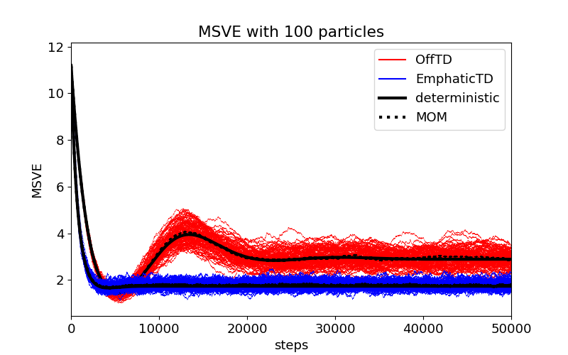

```python
comparator.plot_msve(particles=True, mom = True, optimal=True)
```

As we can see both algorithm do not converge to zero. This is because the features are of dimension 3 while there are 5 states. Thus, it is not solvable perfectly. We can compute what is the theoric minimum of this function by using the Model class.

### - Theoritical limit

As you can see below, the minimum theoric of the MSVE is 0.67. Then it is expected that both algorithms won't converge to zero. Also you can see that they do not converge toward the same $\theta$.

```python
x_min, y_min = model.msve_min()
off_limit = off.optimal(model)
emp_limit = emp.optimal(model)

print("MSVE :")
print("\t Minimum : {}".format(y_min))
print("\t Theta optimal : {}".format(x_min))
print("\t Theta Emphatic limit : {}".format(emp_limit))
print("\t Theta Off limit : {}".format(off_limit))
```

```
MSVE :
	 Minimum : 0.6652329749109185
	 Theta optimal : [3.57777745 0.26666731 0.82222322]
	 Theta Emphatic limit : [2.27183992 0.90775988 0.12152269]
	 Theta Off limit : [ 2.17241379 -0.4137931   1.27586207]
```

### - Plotting of one dimension of $\theta$

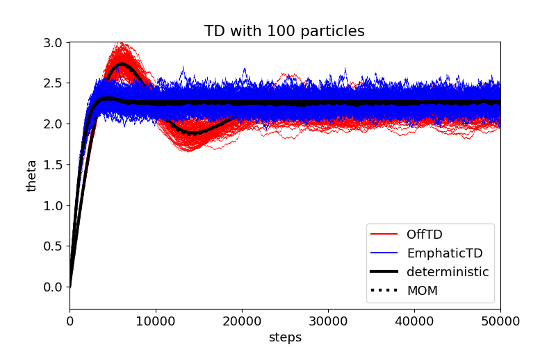

```python
i = 0
comparator.plot_theta(i, particles=True, mom = True, optimal=True)
```

### - Tuning hyper-parameters of the Emphatic-TD on a five states model

```python
# Define the model
model = Model(
            ## Model definition
                # features function
                features = np.identity(5),
                R = np.ones((5,5)), # transition reward
                pi = LeftRightPolicy(p_right = 1), # target policy
                mu = LeftRightPolicy(p_left = 2/3), # behavior policy
                v_pi = [4, 3, 2, 1, 1], # state value under pi

            ## Parameters for TD
                I = np.ones(5), # interest function
                discounts = [0, 1, 1, 1, 0], # discount function

            ## Initialisation
                S0 = 0,
                theta0 = np.zeros(5),
             )
```

#### * Tuning $\alpha$

```python
# The algorithm we want to compare
alphas = [0.1, 0.05, 0.01, 0.005, 0.001]
colors = ['#d73027','#fc8d59','green','#91bfdb','#4575b4']

algos = []
for x in alphas:
    algos.append(EmphaticTD(alpha=x, lambdas=0))

# defining the comparator
comparator = comparatorTD(algos, colors=colors, names=alphas)

# Run the comparator
comparator.run(model, T=2000, N=100)
```

```
emphatic TD has been computed for 2000 steps and 100 particles.
emphatic TD has been computed for 2000 steps and 100 particles.
emphatic TD has been computed for 2000 steps and 100 particles.
emphatic TD has been computed for 2000 steps and 100 particles.
emphatic TD has been computed for 2000 steps and 100 particles.
```

#### * Checking the perfomance by plotting the MSVE

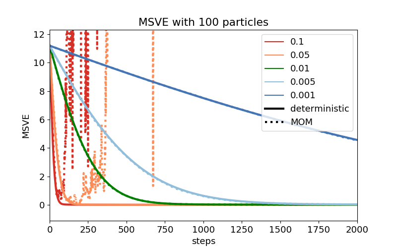

```python
comparator.plot_msve(particles=False, mom=True, optimal=True)
```

As when can see when $\alpha$ is too big, the emphatic becomes unstable. Here the best choice would be $\alpha = 0.01$.

- #### Tuning $\lambda$

```python
# The algorithm you want to compare
lambdas = [0, 0.25, 0.5, 0.75, 1]
colors = ['#d73027','#fc8d59','green','#91bfdb','#4575b4'] # Nice palette
algos = []
for x in lambdas:
    algos.append(EmphaticTD(alpha = 0.01, lambdas=x))

# Build the comparator
comparator = comparatorTD(algos, colors = colors, names = lambdas)

# Run the comparator
comparator.run(model, T = 2000, N = 100)
```

```
emphatic TD has been computed for 2000 steps and 100 particles.
emphatic TD has been computed for 2000 steps and 100 particles.
emphatic TD has been computed for 2000 steps and 100 particles.
emphatic TD has been computed for 2000 steps and 100 particles.
emphatic TD has been computed for 2000 steps and 100 particles.
```

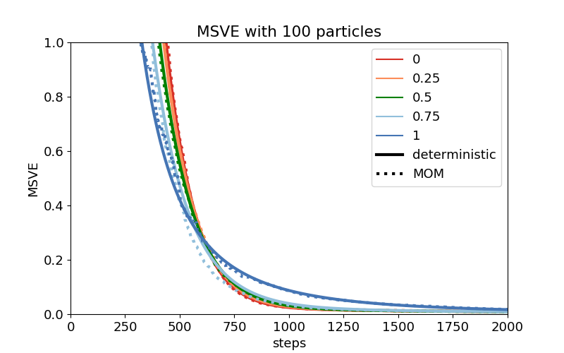

```python
comparator.plot_msve(particles=False, mom = True, optimal=True, ylim=(0, 1))
```

- Comment on results and intuition

The comparator can plot quickly the performance for different hyper-parameters. However with a lot of parameter it can become difficult to optimize.

These results show tha although emphatic TD($\lambda$) is stable for any MDP and all functions $\lambda, \gamma$ , for some problems and functions the parameter vector continues to fluxuate with a chance of arbitrary large deviations (for constant $\alpha>0$). It is not clear how great of a problem this is. Certainly it is much less of problem than the positive instability that can occur with off-policy TD($\lambda$)(stability of the expected update precludes this). The possibility of large fluxuations may be inherent in any algorithm for off-policy learning using importance sampling with long eligibility traces.

In practice, however, even when asymptotic convergence can be guarenteed, high variance can be problematic as it may require very small step sizes and slow learning. High variance frequently arises in off-policy algorithms they have eligibility traces with high $\lambda$.

- Perspectives

The second idea for future work is the emphasis algorithm, by tracing the dependencies among the estimates at various states, is doing something clever that ought to show up as improved bounds on the asymptotic approximation error.